# Reproducible Research Project 1

We know that there are large number of rows that contain missing data. Activity_data is the data table which contains the NA values. first steps is to find the total number of missing values and find the percentage of missing values as compared to the total number of data.

```r
  NA_Values <- sum(is.na(Activity_data$steps))
  NA_Values
```

```
## [1] 2304
```

```r
  Percent_NA<-NA_Values/nrow(Activity_data)
  print("percentage of NA values is ")
```

```
## [1] "percentage of NA values is "
```

```r
  Percent_NA
```

```
## [1] 0.1311475
```

Now we adopt a simple strategy of filling the missing by using the average value of the interval in place of the Missing data.Activity_data_blank_filled is the new variable created which has the missing values filled with the average value of the interval values of number of steps. The last line of the code sum(is.na(Activity_data_blank_filled$steps)) checks that there are no NA values.

```r
  Activity_data_blank_filled <- Activity_data
  nas <- is.na(Activity_data_blank_filled$steps)
  avg_interval <- tapply(Activity_data_blank_filled$steps, Activity_data_blank_filled$interval, mean, na.rm=TRUE, simplify=TRUE)
  Activity_data_blank_filled$steps[nas] <- avg_interval[as.character(Activity_data_blank_filled$interval[nas])]
  sum(is.na(Activity_data_blank_filled$steps))
```

```
## [1] 0
```

Question 7 Histogram of the total number of steps taken each day after missing values are imputed we use the same function as used in the earlier question 4 for histogram

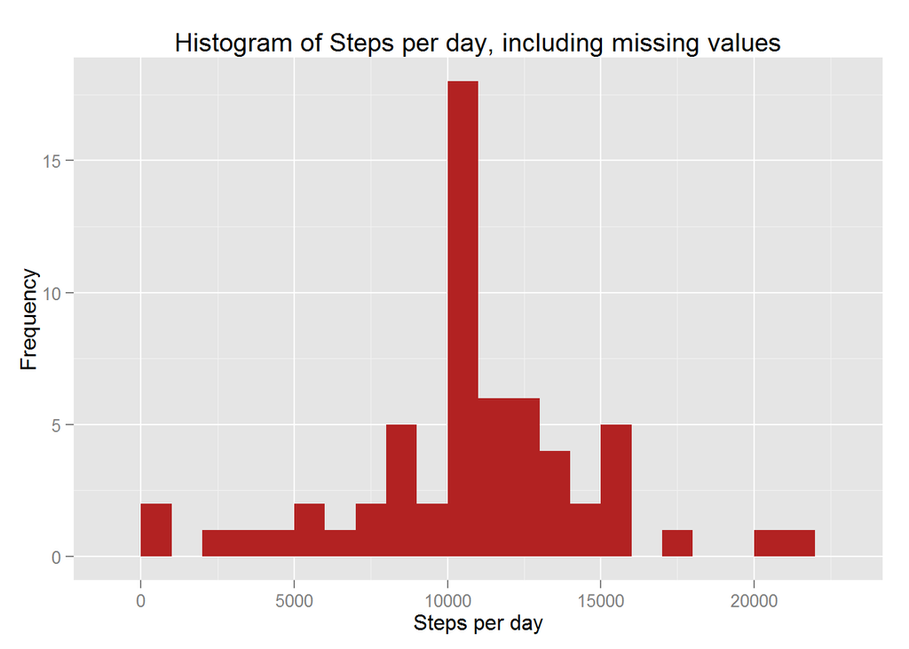

```r
  Date_averages_Steps_blank_filled <- aggregate(x=list(steps=Activity_data_blank_filled$steps),by=list(date=Activity_data_blank_filled$date),FUN=sum, na.rm=TRUE)
  ggplot(data=Date_averages_Steps_blank_filled, aes(x=steps)) +
      geom_histogram(fill="firebrick", binwidth = 1000) +
      labs(title = "Histogram of Steps per day, including missing values", x = "Steps per day", y = "Frequency")
```

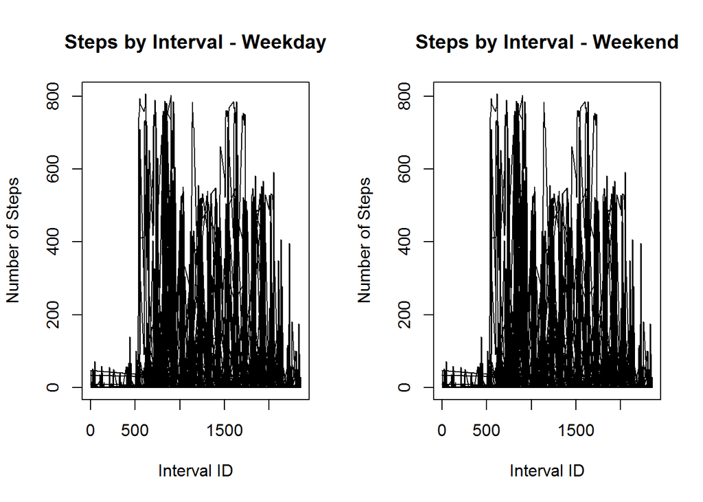

```r
  Activity_data_weektype<-Activity_data_blank_filled
  Activity_data_weektype$date<-ymd(Activity_data_weektype$date)
  Activity_data_weektype <- mutate(Activity_data_weektype, weektype = ifelse(weekdays(Activity_data_weektype$date) == "Saturday" | weekdays(Activity_data_weektype$date) == "Sunday", "weekend", "weekday"))
  Activity_data_weektype$weektype<-as.factor(Activity_data_weektype$weektype)
  Activity_data_weekday<-subset(Activity_data_weektype, weektype="weekday")
  Activity_data_weekend<-subset(Activity_data_weektype, weektype="weekend")
  par(mfrow=c(1,2))
  plot(Activity_data_weekday$interval, Activity_data_weekday$steps,  type="l", main="Steps by Interval - Weekday", xlab="Interval ID", ylab="Number of Steps")

plot(Activity_data_weekend$interval, Activity_data_weekend$steps, type="l", main="Steps by Interval - Weekend", xlab="Interval ID", ylab="Number of Steps")
```